# STA 141A-Final Project

Jinnie 920620900

# Introduction

The study conducted by Steinmetz et al. (2019) explores how neural activity correlates with decision-making processes in mice. The experimental setup was designed to investigate the neural mechanisms underlying visual perception and behavioral choices. By combining high-density neural recordings with a carefully controlled behavioral task, the researchers were able to capture both the neural and behavioral responses of mice as they interacted with visual stimuli.

At the core of the experiment was a decision-making task that required mice to respond to visual stimuli presented on two screens positioned on either side of the animal. The stimuli varied in contrast levels, which were randomly assigned values from the set {0, 0.25, 0.5, 1}. A contrast level of 0 indicated the absence of a stimulus, while higher values represented increasingly salient visual cues. The mice were trained to use a wheel controlled by their forepaws to indicate their decisions based on the relative contrast levels of the stimuli.

The task was designed to test the mice’s ability to discriminate between the contrasts on the left and right screens. Specifically:

- If the left contrast was greater than the right contrast, the correct response was to turn the wheel to the right.
- If the right contrast was greater than the left contrast, the correct response was to turn the wheel to the left.
- If both contrasts were zero, the correct response was to hold the wheel still.
- If the contrasts were equal but non-zero, the correct response was randomly assigned to either left or right with equal probability.

The study involved a total of 10 mice, with data collected over 39 sessions. Each session comprised several hundred trials, ensuring a robust dataset for analysis. For the purposes of this project, a subset of the data was used, consisting of 18 sessions from four mice: Cori, Frossman, Hence, and Lederberg. The experiments consist of a single mouse receiving stimuli (left and right contrast) to test an outcome (feedback type). The neural activity (spks), time of activity (time), and the area of the brain where the neuron lives (brain_area) are also all recorded.

The primary objective of the project is to build a predictive model to predict to outcome of each trial using the neural activity and stimuli data.

# Exploratory Data Analysis

### (1) Describe the data structures across sessions

I opened up the first session to see the structure of the data, and I was able to break down the meaning of each variable. Feedback-type, Contrast_left, and Contrast_right are all vectors of 114 numbers. The mouse name and date_exp are both characters. The brain_area was a vector of 734 characters. The spks is a list of 114 matrices of 734 by 40 matrices. Finally, the time was a list of 114 vectors of 40 numbers.

This showed me that the number of neurons is 734, number of trials is 114, and there are 40 time bins in this session. Using that knowledge, I was able to figure out how to extract this information as well.

1. Explore number of neurons and number of trials

```
##    session n_trials n_neurons
## 1        1      114       734
## 2        2      251      1070
## 3        3      228       619
## 4        4      249      1769
## 5        5      254      1077
## 6        6      290      1169
## 7        7      252       584
## 8        8      250      1157
## 9        9      372       788
## 10      10      447      1172
## 11      11      342       857
## 12      12      340       698
## 13      13      300       983
## 14      14      268       756
## 15      15      404       743
## 16      16      280       474
## 17      17      224       565
## 18      18      216      1090
```

This gave me a summary of the number of trials and neurons of each session in the file.

2. Explore Stimulus Conditions and Feedback Types

```
## # A tibble: 32 × 4
##    contrast_left contrast_right feedback_type     n
##            <dbl>          <dbl>         <dbl> <int>
##  1          0              0               -1   470
##  2          0              0                1   901
##  3          0              0.25            -1    52
##  4          0              0.25             1   142
##  5          0              0.5             -1    53
##  6          0              0.5              1   273
##  7          0              1               -1   115
##  8          0              1                1   339
##  9          0.25           0               -1    66
## 10          0.25           0                1   113
## # ℹ 22 more rows
```

feed_back summary has a table with the number of trials that correspond to each feedback and contrast L/R combination. We can see that the only inputs for contrast left and right are 0.00, 0.25, 0.50, or 1.00.

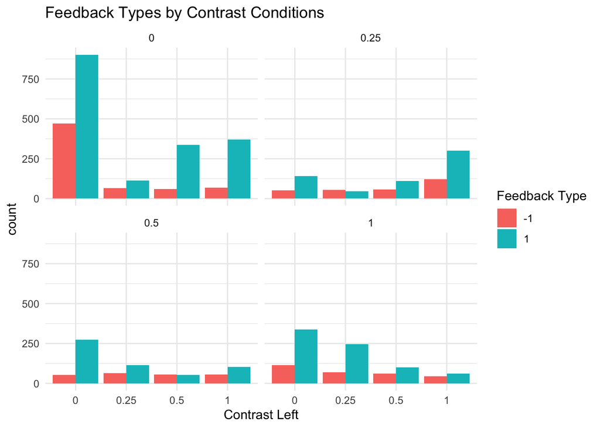

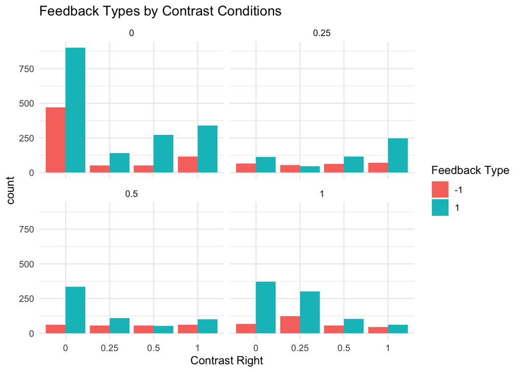

### (2) Explore Neural Activity During Each Trial

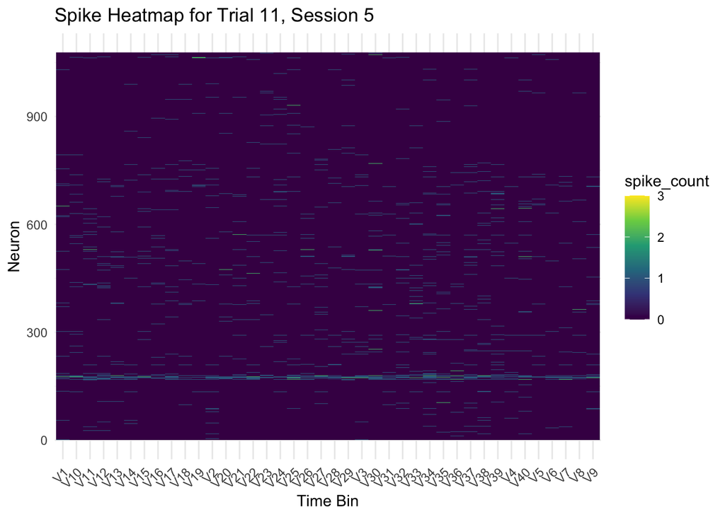

I made a heatmap to show the changes of spikes in neural activity in a specific trial using session5’s trial 11 as an example. One pattern I was able to notice here is that there seems to be a few neurons around the 150-200 range on neuron number that consistently spike throughout the trial.

[figure not shown]

I wanted to check a different trial from a different session to see if the same patter I found was still there, and it seems there is. There are a certain group of neurons that consistently go off throughout the trial although the range of the neurons may change by trial. Another thing I found is that the neural activity is quite similar in within a session’s trials.

### (3) Explore Changes Across Trials

1. Compute the average spike count per trial (across all neurons) for each session.

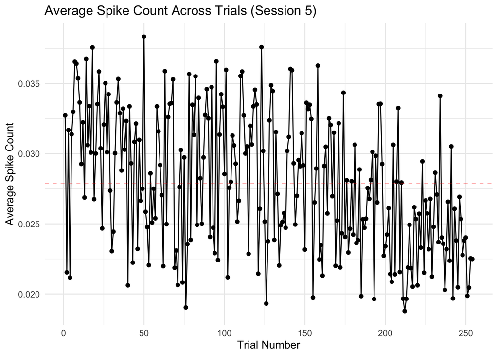

When we look at the overall average spike count in the session versus each individual trial’s average, we can see that there is not much deviation from the population to true average.

I also wanted to see the relationship between spikes and feedback type in a session.

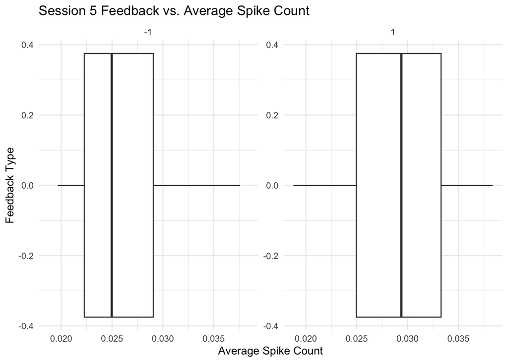

This will show you the pattern of how spike count correlates with the feedback type . I used session5’s data, and found that higher average spike count in a trial correlates with feedback type 1. The opposite is true for feedback type of -1.

### (4) Explore Homogeneity and Heterogeneity Across Sessions and Mice

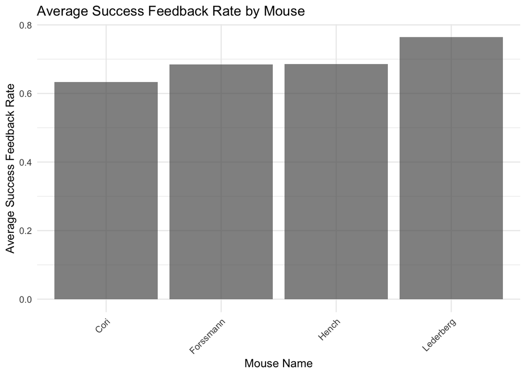

The graph above suggests each mouse has a different average success rate. I can also see that the average success rate increases based on order of session.

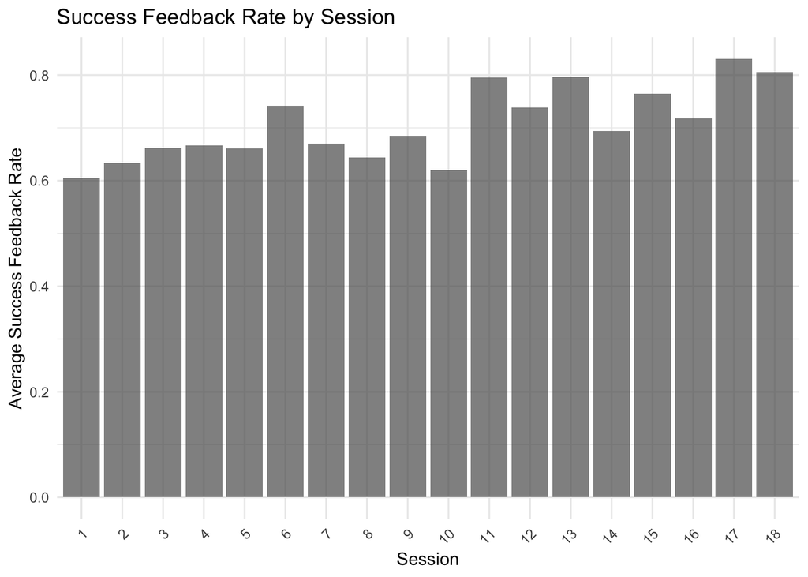

This shows a pattern that the average success feedback rate increases as session increases. This makes sense since the lowest success rate mouse was studied first and the highest success rate mouse was studied last respectively.

# Data Integration

```r
pred_data_list <- list()

for (i in 1:18) {
  sess <- session[[i]]
  for (j in 1:length(sess$spks)) {
    spike_matrix <- sess$spks[[j]]
    avg_spike <- mean(spike_matrix)
    pred_data_list[[length(pred_data_list) + 1]] <- data.frame(
      session = i,
      trial = j,
      contrast_left = sess$contrast_left[j],
      contrast_right = sess$contrast_right[j],
      avg_spike = avg_spike
    )
  }
}

pred_data <- bind_rows(pred_data_list)
```

Across sessions and trials, I combined the specific data I want to use for my predictive model which are the contrast left, contrast right, and average spike per trial per session.

# Predictive Modeling

```
## [1] "Success Trials Summary:"
```

```
##  decision   avg_spikes
##  1:64     Min.   :0.7239
##  2:63     1st Qu.:1.0170
##  3:43     Median :1.1280
##  4: 4     Mean   :1.1143
##           3rd Qu.:1.2163
##           Max.   :1.5284
```

```
## [1] "Failed Trials Summary:"
```

```
##  decision   avg_spikes
##  1: 8     Min.   :0.6872
##  2: 8     1st Qu.:0.8933
##  3:20     Median :1.0404
##  4: 6     Mean   :1.0225
##           3rd Qu.:1.1303
##           Max.   :1.3835
```

```
## [1] 0.8055556
```

I first set a random seed to ensure reproducibility. Then, I randomly selected 80% of the dataset for training with no replacement. Finally, I split the dataset into a training dataset (80% of the data) and test dataset (the remaining 20%). I also made the feedback type binary so that the outcome -1 is now 0 to signify a failed trial.

```
##
## Call:
## glm(formula = feedback_type ~ ., family = "binomial", data = train1)
##
## Coefficients:
##             Estimate Std. Error z value Pr(>|z|)
## (Intercept)  -1.4926     1.5915  -0.938  0.34830
## decision2    -0.4299     0.6360  -0.676  0.49914
## decision3    -1.1494     0.5083  -2.261  0.02374 *
## decision4    -2.8147     0.8677  -3.244  0.00118 **
## avg_spikes    3.3630     1.5080   2.230  0.02574 *
## ---
## Signif. codes:  0 '***' 0.001 '**' 0.01 '*' 0.05 '.' 0.1 ' ' 1
##
## (Dispersion parameter for binomial family taken to be 1)
##
##     Null deviance: 173.79  on 171  degrees of freedom
## Residual deviance: 151.77  on 167  degrees of freedom
## AIC: 161.77
##
## Number of Fisher Scoring iterations: 4
```

```
## [1] 0.8409091
```

```
##          Actual
## Predicted -1  1
##        -1  1  1
##        1   6 36
```

The confusion matrix above shows that the model is likely to predict a failed trial as a success.

```
##
## Call:
## glm(formula = feedback_type ~ ., family = "binomial", data = train2)
##
## Coefficients:
##             Estimate Std. Error z value Pr(>|z|)
## (Intercept)  -2.2528     1.6441  -1.370  0.17060
## decision2    -0.5337     0.6443  -0.828  0.40747
## decision3    -1.1300     0.5114  -2.210  0.02714 *
## avg_spikes    4.1111     1.5735   2.613  0.00898 **
## ---
## Signif. codes:  0 '***' 0.001 '**' 0.01 '*' 0.05 '.' 0.1 ' ' 1
##
## (Dispersion parameter for binomial family taken to be 1)
##
##     Null deviance: 156.06  on 163  degrees of freedom
## Residual deviance: 139.25  on 160  degrees of freedom
## AIC: 147.25
##
## Number of Fisher Scoring iterations: 5
```

Immediately, I can see that the null deviance, residual deviance, and AIC is lower than the unfiltered model.

```
## [1] 0.8571429
```

```
##          Actual
## Predicted -1  1
##        -1  0  0
##        1   6 36
```

Same as before, we can see that the model is likely to predict a failed trial as a success.

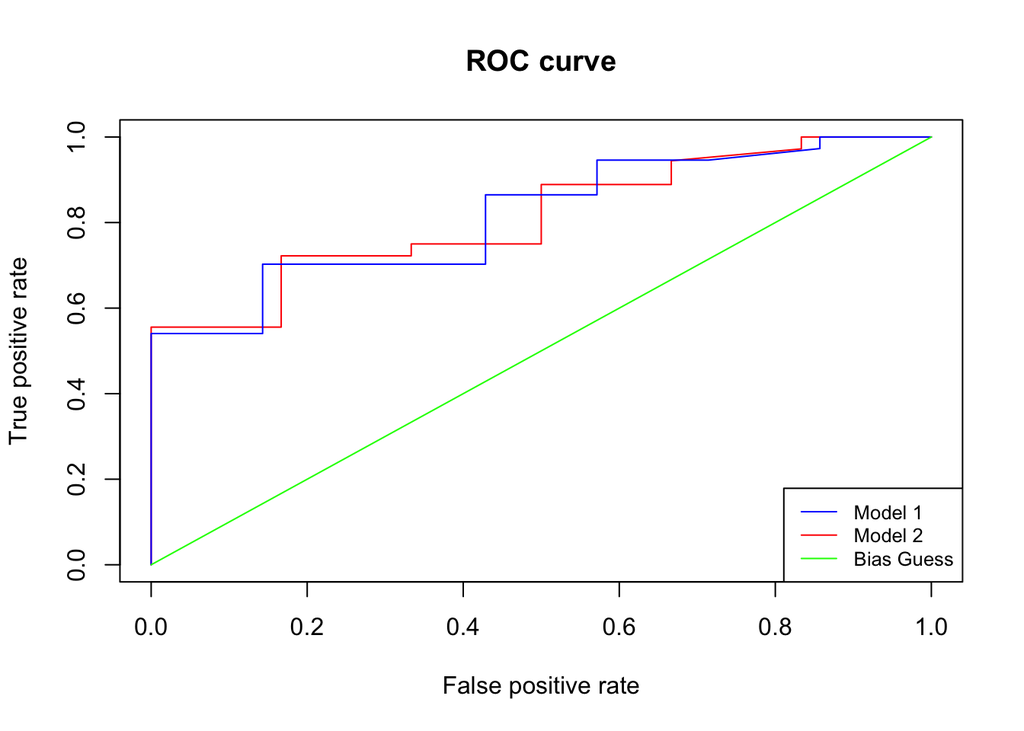

```
## [1] "AUC Model 1: "
```

```
## [1] 0.8166023
```

```
## [1] "AUC Model 2: "
```

```
## [1] 0.8125
```

Overall, Model 2 is a better fit since it has lower null and residual deviance, lower AIC, and slightly higher prediction accuracy even though Model 1 has a slightly higher AUC.

# Prediction Performace on test set

### (1) Test 1 performance on prediction model.

##### (a) Generalized Linear Model of Test 1

```
##
## Call:
## glm(formula = feedback_type ~ ., family = "binomial", data = t_train1_clean)
##
## Coefficients:
##             Estimate Std. Error z value Pr(>|z|)
## (Intercept)  -7.4939     2.7483  -2.727  0.00640 **
## decision2    -0.4467     0.7586  -0.589  0.55597
## decision3     2.1684     1.0921   1.986  0.04707 *
## avg_spikes    5.8474     1.8472   3.166  0.00155 **
## ---
## Signif. codes:  0 '***' 0.001 '**' 0.01 '*' 0.05 '.' 0.1 ' ' 1
##
## (Dispersion parameter for binomial family taken to be 1)
##
##     Null deviance: 86.362  on 73  degrees of freedom
## Residual deviance: 63.574  on 70  degrees of freedom
## AIC: 71.574
##
## Number of Fisher Scoring iterations: 5
```

##### (b) Test 1 Accuracy on Model

```
## [1] 0.85
```

##### (c) Confusion Matrix

```
##          Actual
## Predicted -1  1
##        -1  2  1
##        1   2 15
```

##### (d) ROC Curve

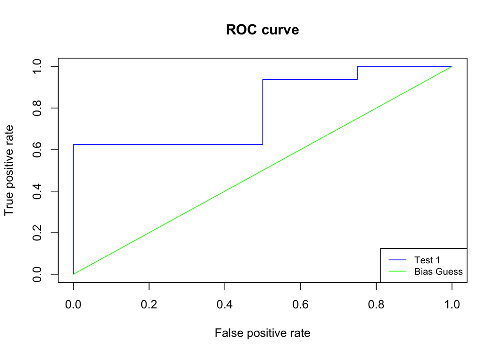

##### (e) AUC Value

```
## [1] 0.796875
```

### (2) Test 2 performance on prediction model.

##### (a)Generalized Linear Model of Test 2

```
##
## Call:
## glm(formula = feedback_type ~ ., family = "binomial", data = t_train2_clean)
##
## Coefficients:
##             Estimate Std. Error z value Pr(>|z|)
## (Intercept)  -1.0723     1.8546  -0.578   0.5632
## decision2     1.9444     1.1150   1.744   0.0812 .
## decision3    -0.7171     0.5751  -1.247   0.2124
## avg_spikes    1.9064     1.7746   1.074   0.2827
## ---
## Signif. codes:  0 '***' 0.001 '**' 0.01 '*' 0.05 '.' 0.1 ' ' 1
##
## (Dispersion parameter for binomial family taken to be 1)
##
##     Null deviance: 90.237  on 76  degrees of freedom
## Residual deviance: 77.433  on 73  degrees of freedom
## AIC: 85.433
##
## Number of Fisher Scoring iterations: 5
```

##### (b) Test 2 Accuracy on Model

```
## [1] 0.65
```

##### (c) Confusion Matrix

```
##          Actual
## Predicted -1  1
##        -1  0  2
##        1   5 13
```

##### (d) ROC Curve

[figure not shown]

##### (e) AUC Value

```
## [1] 0.7066667
```

# Discussion

I chose to do a GLM model since the outcome variable (feedback type) is binary, and using this model shows how specific predictors affect likelihood of success versus failure through the p-value. Also, there is no residual normality assumption which fits better with the binary outcomes.

I also removed certain predictors that may have led to overfitting in the model and reduction of accuracy.

I feel my model worked fairly well on test 1 since the statistically significant predictor variables were similar to the ones on my training model. As a result, the accuracy and AUC value were pretty good. However, test 2 was not very accurate. This difference is probably due to the fact the statistically significant predictors were not the same in this session.

Something that could have made my model better is if it factored in more predictor variables such as mouse since we found out during the EDA that each mouse seems to have a different success rate.

# Acknowledgements

ChatGPT used for debugging code and graph adjustments

# Appendix

```r
library(tidyverse)
library(ggplot2)
session=list()
for(i in 1:18){
  session[[i]]=readRDS(paste('./Data/session',i,'.rds',sep=''))
  print(session[[i]]$mouse_name)
  print(session[[i]]$date_exp)
}


session1 <- session[[1]]
str(session1)


session_summary <- data.frame(
  session = integer(),
  n_trials = integer(),
  n_neurons = numeric()
)

for (i in 1:length(session)) {
  sess <- session[[i]]

  n_trials <- length(sess$spks)

  n_neurons <- nrow(sess$spks[[1]])

  session_summary <-
    rbind(session_summary,
          data.frame(session = i,
                     n_trials = n_trials,
                     n_neurons = n_neurons))
}

print(session_summary)



trial_data_list <- list()

for (i in 1:18) {
  sess <- session[[i]]
  for (j in 1:length(sess$spks)) {
    trial_data_list[[length(trial_data_list) + 1]] <- data.frame(
      session = i,
      trial = j,
      feedback_type = sess$feedback_type[j],
      contrast_left = sess$contrast_left[j],
      contrast_right = sess$contrast_right[j]
    )
  }
}

trial_data <- bind_rows(trial_data_list)

feedback_summary <- trial_data %>%
  group_by(contrast_left, contrast_right, feedback_type) %>%
  summarise(n = n(), .groups="drop")

print(feedback_summary)
ggplot(trial_data, aes(x = factor(contrast_left), fill = factor(feedback_type))) +
  geom_bar(position = "dodge") +
  facet_wrap(~ contrast_right) +
  labs(title = "Feedback Types by Contrast Conditions",
       x = "Contrast Left",
       fill = "Feedback Type") +
  theme_minimal()
ggplot(trial_data, aes(x = factor(contrast_right), fill = factor(feedback_type))) +
  geom_bar(position = "dodge") +
  facet_wrap(~ contrast_left) +
  labs(title = "Feedback Types by Contrast Conditions",
       x = "Contrast Right",
       fill = "Feedback Type") +
  theme_minimal()
selected_session <- session[[5]]
selected_trial <- selected_session$spks[[11]]  # This is a matrix: rows = neurons, columns = time bins

# Convert the spike matrix to a data frame for plotting
spike_df <- as.data.frame(selected_trial)
spike_df$neuron <- 1:nrow(spike_df)
spike_long <- spike_df %>%
  pivot_longer(cols = -neuron, names_to = "time_bin", values_to = "spike_count")

ggplot(spike_long, aes(x = time_bin, y = neuron, fill = spike_count)) +
  geom_tile() +
  scale_fill_viridis_c() +
  labs(title = "Spike Heatmap for Trial 11, Session 5",
       x = "Time Bin",
       y = "Neuron") +
  theme_minimal()+
  theme(axis.text.x = element_text(angle=45, hjust=1))



selected_session <- session[[10]]
selected_trial <- selected_session$spks[[9]]

spike_df <- as.data.frame(selected_trial)
spike_df$neuron <- 1:nrow(spike_df)
spike_long <- spike_df %>%
  pivot_longer(cols = -neuron, names_to = "time_bin", values_to = "spike_count")

ggplot(spike_long, aes(x = time_bin, y = neuron, fill = spike_count)) +
  geom_tile() +
  scale_fill_viridis_c() +
  labs(title = "Spike Heatmap for Trial 3, Session 10",
       x = "Time Bin",
       y = "Neuron") +
  theme_minimal()+
  theme(axis.text.x = element_text(angle=45, hjust=1))



trial_avg_spike <- data.frame(
  session = integer(),
  trial = integer(),
  avg_spike = numeric()
)

for (i in 1:length(session)) {
  sess <- session[[i]]
  for (j in 1:length(sess$spks)) {
    spike_matrix <- sess$spks[[j]]
    avg_spike <- mean(spike_matrix)
    trial_avg_spike <- rbind(trial_avg_spike,
                             data.frame(session = i, trial = j, avg_spike = avg_spike))
  }
}

session5_data <- trial_avg_spike %>% filter(session == 5)
overall_avg <- mean(session5_data$avg_spike)



ggplot(session5_data, aes(x = trial, y = avg_spike)) +
  geom_line() +
  geom_point() +
  geom_hline(yintercept = overall_avg, color = "red", linetype = "dashed", linewidth = 0.1) +
  labs(title = "Average Spike Count Across Trials (Session 5)",
       x = "Trial Number",
       y = "Average Spike Count") +
  theme_minimal()



# trial_avg_spike has columns: session, trial, avg_spike
# trial_data has columns: session, trial, feedback_type, contrast_left, contrast_right, etc.

session_feedback_spikes <- merge(trial_avg_spike, trial_data, by = c("session", "trial"))

sessionx_feedback <- session_feedback_spikes %>% filter(session == 5)

ggplot(sessionx_feedback, aes(group=(x = feedback_type), y = avg_spike)) +
  geom_boxplot() +
  facet_wrap(~ feedback_type, scales = "free_y") +
  labs(title = "Session 5 Feedback vs. Average Spike Count",
       x = "Feedback Type",
       y = "Average Spike Count") +
  theme_minimal() +
  coord_flip()


session_mice_list <- list()

for (i in 1:18) {
  sess <- session[[i]]
  fb <-sess$feedback_type
  session_mice_list[[length(session_mice_list) + 1]] <- data.frame(
      session = i,
      mouse_name = sess$mouse_name,
      feedback = sum(fb=="1")/length(fb)
    )

}

session_mice <- bind_rows(session_mice_list)


mouse_success_rate <- session_mice %>%
  group_by(mouse_name) %>%
  summarise(avg_success_rate = mean(feedback))

ggplot(mouse_success_rate, aes(x = mouse_name, y = avg_success_rate)) +
  geom_bar(stat = "identity", alpha = 0.7) +
  theme_minimal() +
  labs(title = "Average Success Feedback Rate by Mouse",
       x = "Mouse Name",
       y = "Average Success Feedback Rate") +
  theme(axis.text.x = element_text(angle = 45, hjust = 1))


ggplot(session_mice, aes(x = factor(session), y = feedback)) +
  geom_bar(stat = "identity", alpha = 0.7) +
  theme_minimal() +
  labs(title = "Success Feedback Rate by Session",
       x = "Session",
       y = "Average Success Feedback Rate") +
  theme(axis.text.x = element_text(angle = 45, hjust = 1), legend.position = "none")


pred_data_list <- list()

for (i in 1:18) {
  sess <- session[[i]]
  for (j in 1:length(sess$spks)) {
    spike_matrix <- sess$spks[[j]]
    avg_spike <- mean(spike_matrix)
    pred_data_list[[length(pred_data_list) + 1]] <- data.frame(
      session = i,
      trial = j,
      contrast_left = sess$contrast_left[j],
      contrast_right = sess$contrast_right[j],
      avg_spike = avg_spike
    )
  }
}

pred_data <- bind_rows(pred_data_list)
```

```r
library(readr)
library(caret) # confusion matrix
library(ROCR) # ROC curve
library(xgboost)


s = session[[5]]

n_obs = length(sess$feedback_type)

dat = tibble(
    feedback_type = as.factor(sess$feedback_type),
    decision = rep('name', n_obs),
    avg_spikes = rep(0, n_obs)
)

for (i in 1:n_obs){
    if (sess$contrast_left[i] > sess$contrast_right[i]){
        dat$decision[i] = '1'  # Left contrast higher
    } else if (sess$contrast_left[i] < sess$contrast_right[i]){
        dat$decision[i] = '2'  # Right contrast higher
    } else if (sess$contrast_left[i] == sess$contrast_right[i] & sess$contrast_left[i] == 0){
        dat$decision[i] = '3'  # No stimulus
    } else{
        dat$decision[i] = '4'  # Equal non-zero contrast
    }

    # Compute average spikes per trial
    spks.trial = sess$spks[[i]]
    total.spikes = apply(spks.trial, 1, sum)  # Sum spikes per neuron
    dat$avg_spikes[i] = mean(total.spikes)  # Compute mean spikes per trial
}

dat$decision = as.factor(dat$decision)

dat <- dat %>% mutate(feedback_type = as.numeric(as.character(feedback_type)))

# Create separate tables for success and fail trials
success_trials <- dat %>% filter(feedback_type == 1) %>% select(-feedback_type)
failed_trials <- dat %>% filter(feedback_type == -1) %>% select(-feedback_type)

print("Success Trials Summary:")
print(summary(success_trials))

print("Failed Trials Summary:")
print(summary(failed_trials))

num_success <- sum(dat$feedback_type ==1)
num_total <- nrow(dat)

success_rate <- (num_success)/(num_total)
print(success_rate)



set.seed(143)

sample <- sample.int(n = n_obs, size = floor(.8 * n_obs), replace = F)
train1 <- dat[sample, ]
test1  <- dat[-sample, ]
train1$feedback_type <- ifelse(train1$feedback_type == -1, 0, train1$feedback_type)

fit1 <- glm(feedback_type~., data = train1, family="binomial")
summary(fit1)

pred1 <- predict(fit1, test1 %>% select(-feedback_type), type = 'response')
prediction1 <- factor(pred1 > 0.5, labels = c('-1', '1'))
mean(prediction1 == test1$feedback_type)

table(Predicted = prediction1, Actual = test1$feedback_type)
# Filter out decision 4

set.seed(143)
train2 <- train1 %>% filter(decision != 4)
test2 <- test1 %>% filter(decision != 4)


fit2 <- glm(feedback_type ~ ., data = train2, family = "binomial")
summary(fit2)


pred2 <- predict(fit2, test2 %>% select(-feedback_type), type = 'response')
pred_binary <- ifelse(pred2 > 0.5, 1, -1)  # Ensure correct labels
prediction2 <- factor(pred_binary, levels = c('-1', '1'))
mean(prediction2 == test2$feedback_type)

table(Predicted = prediction2, Actual = test2$feedback_type)
# Model 1
pr = prediction(pred1, test1$feedback_type)
prf <- performance(pr, measure = "tpr", x.measure = "fpr")
auc <- performance(pr, measure = "auc")
auc <- auc@y.values[[1]]

# Model 2
pr = prediction(pred2, test2$feedback_type)
prf2 <- performance(pr, measure = "tpr", x.measure = "fpr")
auc2 <- performance(pr, measure = "auc")
auc2 <- auc2@y.values[[1]]

# Bias Guess
pred0 = pred1 * 0 + 1
pr = prediction(pred0, test1$feedback_type)
prf0 <- performance(pr, measure = "tpr", x.measure = "fpr")
auc0 <- performance(pr, measure = "auc")
auc0 <- auc0@y.values[[1]]

plot(prf2, ,col = 'red', main = 'ROC curve')
plot(prf, add = TRUE, col = 'blue')
plot(prf0, add = TRUE, col = 'green')
legend("bottomright", legend=c("Model 1", "Model 2", "Bias Guess"), col=c("blue", "red", 'green'), lty=1:1,
       cex=0.8)

print("AUC Model 1: ")
print(auc)

print("AUC Model 2: ")
print(auc2)


test.data=list()
for(i in 1:2){
  test.data[[i]]=readRDS(paste('./test/test',i,'.rds',sep=''))
  print(test.data[[i]]$mouse_name)
  print(test.data[[i]]$date_exp)
}


t = test.data[[1]]

n_obs1 = length(t$feedback_type)

dat1 = tibble(
    feedback_type = as.factor(t$feedback_type),
    decision = rep('name', n_obs1),
    avg_spikes = rep(0, n_obs1)
)

for (i in 1:n_obs1){
    if (t$contrast_left[i] > t$contrast_right[i]){
        dat1$decision[i] = '1'  # Left contrast higher
    } else if (t$contrast_left[i] < t$contrast_right[i]){
        dat1$decision[i] = '2'  # Right contrast higher
    } else if (t$contrast_left[i] == t$contrast_right[i] & t$contrast_left[i] == 0){
        dat1$decision[i] = '3'  # No stimulus
    } else{
        dat1$decision[i] = '4'  # Equal non-zero contrast
    }

    # Compute average spikes per trial
    spks.trial = t$spks[[i]]
    total.spikes = apply(spks.trial, 1, sum)  # Sum spikes per neuron
    dat1$avg_spikes[i] = mean(total.spikes)  # Compute mean spikes per trial
}

dat1$decision = as.factor(dat1$decision)

dat1 <- dat1 %>% mutate(feedback_type = as.numeric(as.character(feedback_type)))



set.seed(143)

sample <- sample.int(n = n_obs1, size = floor(.8 * n_obs1), replace = F)
t_train1 <- dat1[sample, ]
t_test1  <- dat1[-sample, ]
t_train1$feedback_type <- ifelse(t_train1$feedback_type == -1, 0, t_train1$feedback_type)

# Filter out decision 4
t_train1_clean <- t_train1 %>% filter(decision != 4)
t_test1_clean <- t_test1 %>% filter(decision != 4)


t_fit1 <- glm(feedback_type ~ ., data = t_train1_clean, family = "binomial")
summary(t_fit1)


t_pred1 <- predict(t_fit1, t_test1_clean %>% select(-feedback_type), type = 'response')
t_pred_binary1 <- ifelse(t_pred1 > 0.5, 1, -1)  # Ensure correct labels
t_prediction1 <- factor(t_pred_binary1, levels = c('-1', '1'))
mean(t_prediction1 == t_test1_clean$feedback_type)

table(Predicted = t_prediction1, Actual = t_test1_clean$feedback_type)
# Model 1
pr = prediction(t_pred1, t_test1_clean$feedback_type)
t_prf1 <- performance(pr, measure = "tpr", x.measure = "fpr")
t_auc1 <- performance(pr, measure = "auc")
t_auc1 <- t_auc1@y.values[[1]]

# Bias Guess
pred0 = pred1 * 0 + 1
pr = prediction(pred0, test1$feedback_type)
prf0 <- performance(pr, measure = "tpr", x.measure = "fpr")
auc0 <- performance(pr, measure = "auc")
auc0 <- auc0@y.values[[1]]


plot(t_prf1, col = "blue", main = 'ROC curve')
plot(prf0, add = TRUE, col = 'green')
legend("bottomright", legend=c("Test 1","Bias Guess"), col=c("blue",  'green'), lty=1:1,
       cex=0.8)
```

```r
print(c(t_auc1))

t2 = test.data[[2]]

n_obs2 = length(t2$feedback_type)

dat2 = tibble(
    feedback_type = as.factor(t2$feedback_type),
    decision = rep('name', n_obs2),
    avg_spikes = rep(0, n_obs2)
)

for (i in 1:n_obs2){
    if (t2$contrast_left[i] > t2$contrast_right[i]){
        dat2$decision[i] = '1'  # Left contrast higher
    } else if (t2$contrast_left[i] < t2$contrast_right[i]){
        dat2$decision[i] = '2'  # Right contrast higher
    } else if (t2$contrast_left[i] == t2$contrast_right[i] & t2$contrast_left[i] == 0){
        dat2$decision[i] = '3'  # No stimulus
    } else{
        dat2$decision[i] = '4'  # Equal non-zero contrast
    }

    # Compute average spikes per trial
    spks.trial = t2$spks[[i]]
    total.spikes = apply(spks.trial, 1, sum)  # Sum spikes per neuron
    dat2$avg_spikes[i] = mean(total.spikes)  # Compute mean spikes per trial
}

dat2$decision = as.factor(dat2$decision)

dat2 <- dat2 %>% mutate(feedback_type = as.numeric(as.character(feedback_type)))



set.seed(143)

sample <- sample.int(n = n_obs2, size = floor(.8 * n_obs2), replace = F)
t_train2 <- dat2[sample, ]
t_test2  <- dat2[-sample, ]
t_train2$feedback_type <- ifelse(t_train2$feedback_type == -1, 0, t_train2$feedback_type)

# Filter out decision 4
t_train2_clean <- t_train2 %>% filter(decision != 4)
t_test2_clean <- t_test2 %>% filter(decision != 4)


t_fit2 <- glm(feedback_type ~ ., data = t_train2_clean, family = "binomial")
summary(t_fit2)


t_pred2 <- predict(t_fit2, t_test2_clean %>% select(-feedback_type), type = 'response')
t_pred_binary2 <- ifelse(t_pred2 > 0.5, 1, -1)  # Ensure correct labels
t_prediction2 <- factor(t_pred_binary2, levels = c('-1', '1'))
mean(t_prediction2 == t_test2_clean$feedback_type)

table(Predicted = t_prediction2, Actual = t_test2_clean$feedback_type)
# Model 1
pr = prediction(t_pred2, t_test2_clean$feedback_type)
t_prf2 <- performance(pr, measure = "tpr", x.measure = "fpr")
t_auc2 <- performance(pr, measure = "auc")
t_auc2 <- t_auc2@y.values[[1]]

# Bias Guess
pred0 = pred1 * 0 + 1
pr = prediction(pred0, test1$feedback_type)
prf0 <- performance(pr, measure = "tpr", x.measure = "fpr")
auc0 <- performance(pr, measure = "auc")
auc0 <- auc0@y.values[[1]]


plot(t_prf2, col = "blue", main = 'ROC curve')
plot(prf0, add = TRUE, col = 'green')
legend("bottomright", legend=c("Test 1","Bias Guess"), col=c("blue",  'green'), lty=1:1,
       cex=0.8)

print(c(t_auc2))
```